# STSCI 5030 - Fall 2018 - HW3 Q3

Harry Lu, dl947

Due Friday, October 12, 2018

This question will perform a simulation based on the model in Question 2. Here we will see in simulation that the way we quantify uncertainty really is reasonable.

# a

> Create 1000 new data sets each with the values of $log(G)$ and $log(W)$ using the coefficients and residual standard error estimated in Question 2 to produce the values in $y$ (you will need to re-load the data and re-run `lm` to get this). On each data set, conduct an linear regression and record the estimated $\hat{\beta}$ its standard error, and $\hat{\sigma}$.

```r
brain_data=read.table("https://raw.githubusercontent.com/HarryLu95/dalu/master/CU/5030/BrainWeight.txt",head=TRUE)
#colnames(brain_data)=c("B","W","G")
brain_data$ln_B=log(brain_data$Brain,base=exp(1))
brain_data$ln_W=log(brain_data$Body,base=exp(1))
brain_data$ln_G=log(brain_data$Gestation,base=exp(1))
brain_mod=lm(ln_B~ln_W+ln_G,data=brain_data)
sigma=summary(brain_mod)$sigma
```

```r
set.seed(1)
B=matrix(0,nrow=1000,ncol=10)
for (i in 1:1000){
  temp_y=brain_mod$fitted.values+rnorm(96,mean=0,sd=sigma)
  temp_summary=summary(lm(temp_y~brain_data$ln_W+brain_data$ln_G))
  temp_beta0=temp_summary$coefficients[1,1]
  temp_se_beta0=temp_summary$coefficients[1,2]
  temp_var_beta0=temp_se_beta0^2
  temp_beta1=temp_summary$coefficients[2,1]
  temp_se_beta1=temp_summary$coefficients[2,2]
  temp_var_beta1=temp_se_beta1^2
  temp_beta2=temp_summary$coefficients[3,1]
  temp_se_beta2=temp_summary$coefficients[3,2]
  temp_var_beta2=temp_se_beta2^2
  temp_sigma=temp_summary$sigma
  B[i,]=c(temp_beta0,temp_se_beta0,temp_var_beta0,temp_beta1,temp_se_beta1,temp_var_beta1,temp_beta2,temp_se_beta2,temp_var_beta2,temp_sigma)
}
rm(i,temp_y,temp_summary,temp_beta0,temp_se_beta0,temp_var_beta0,temp_beta1,temp_se_beta1,temp_var_beta1,temp_beta2,temp_se_beta2,temp_var_beta2,temp_sigma)
colnames(B)=c("beta0","se_beta0","var_beta0","beta1","se_beta1","var_beta1","beta2","se_beta2","var_beta2","sigma")
```

# b

> Produce a scatter plot of the $\hat{\beta}_1$ and $\hat{\beta}_2$ values. Report their covariance. How does this relate to the relationship between log(G) and log(W)?

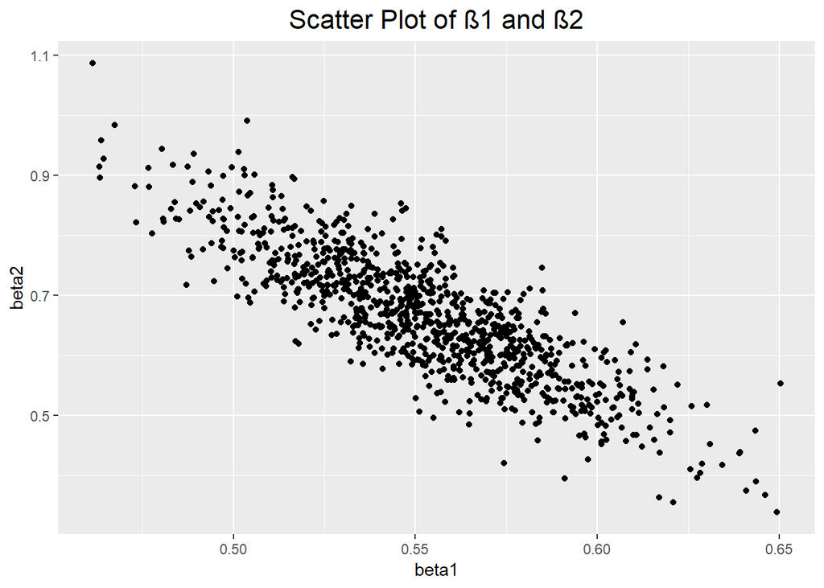

```r
library(ggplot2)
d=as.data.frame(cbind(1:1000,B))
colnames(d)[1]="index"
ggplot(data=d)+
  geom_point(aes(x=beta1,y=beta2))+
  ggtitle("Scatter Plot of β1 and β2")+
  theme(plot.title=element_text(size=16,hjust=0.5))
```

Since $\hat{\beta_1}$ and $\hat{\beta_2}$ are negative correlated, the corresponding variables (`ln_W` and `ln_G`) are positive correlated, which is 0.8455317.

# c

> Construct scatterplots of $\hat{\sigma}$ versus each of $\hat{\beta}_1$ and $\hat{\beta}_2$. Is there a relationship here?

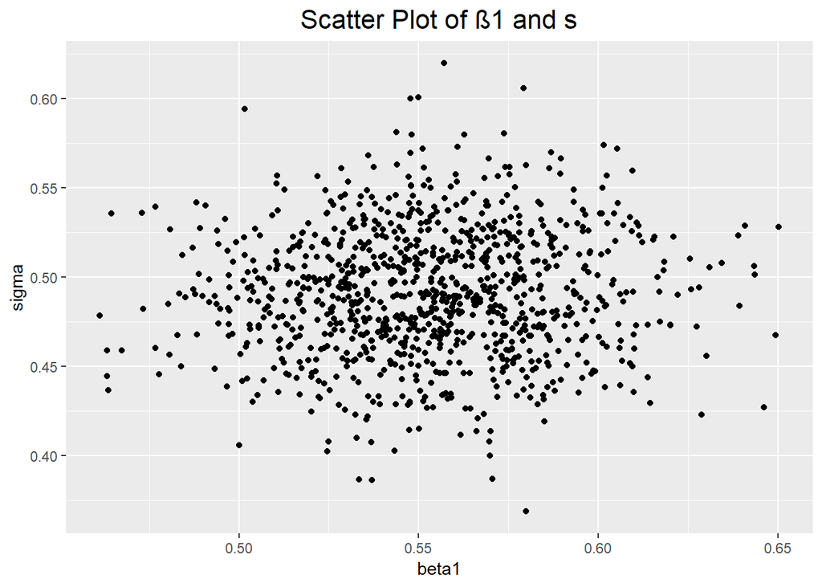

```r
ggplot(data=d)+
  geom_point(aes(x=beta1,y=sigma))+
  ggtitle("Scatter Plot of β1 and σ")+
  theme(plot.title=element_text(size=16,hjust=0.5))
```

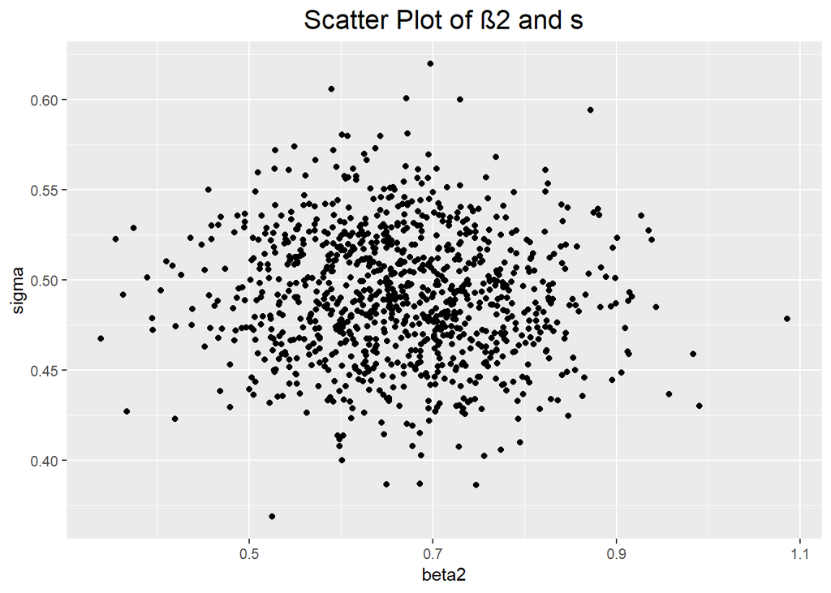

```r
ggplot(data=d)+
  geom_point(aes(x=beta2,y=sigma))+
  ggtitle("Scatter Plot of β2 and σ")+
  theme(plot.title=element_text(size=16,hjust=0.5))
```

There is no relationship between $\hat{\beta}$ and $\hat{\sigma}$.

# d

> Construct a histogram of the 1000 $t$-statistics,

> $$T_i = \frac{ \widehat{\beta_1}_i - \beta_1 }{\mbox{se}(\widehat{\beta_1}_i)}$$

> where $\beta_1$ is the coefficient for height. Overlay a t-density with the appropriate degrees of freedom.
- $\widehat{\beta_1}_i$ -> `d$beta1`
- $\beta_1$ -> $\beta_1$ from the original model
- $\text{se}(\widehat{\beta_1}_1)$ -> `d$se_beta1`

Degree of freedom should be 93.

```r
T_s=c()
beta_1=summary(brain_mod)$coefficient[2,1]
for (i in 1:1000){
  T_s[i]=(d$beta1[i]-beta_1)/d$se_beta1[i]
}
rm(i)
```

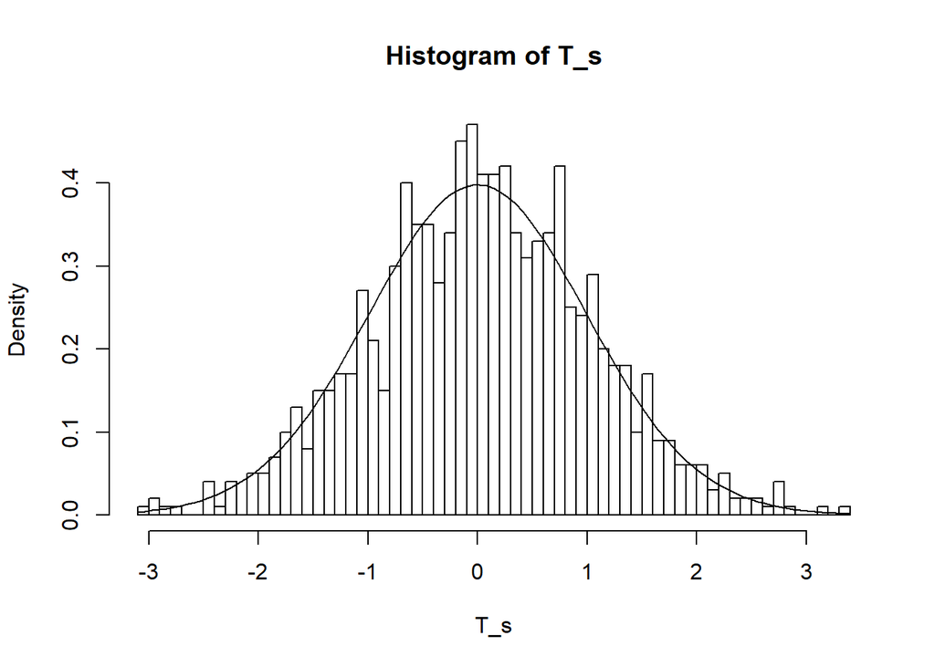

```r
hist(T_s,breaks=50,probability=TRUE)
curve(dt(x,93),add=T)
```

# e

> Use the qqnorm function to construct a QQ plot of the 1000 simulated t-statistics and add a line through the origin with unit slope.

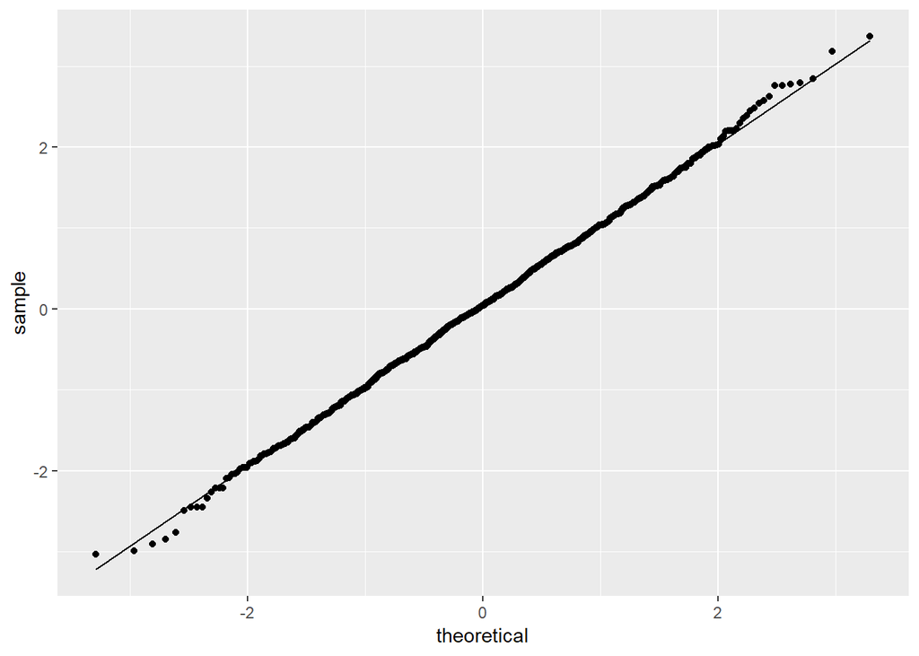

```r
T_s=as.data.frame(T_s)
ggplot(data=T_s,aes(sample=T_s))+
  geom_qq()+
  geom_qq_line()
```

# f

> Construct a histogram of the 1000 chi-squared statistics of the form

> $$\chi^2 = f * \frac{\hat{\sigma}^2_i}{\sigma^2}$$

> where $\sigma^2$ is the variance used to generate your errors, and f is the error degrees of freedom. Overlay a chi-squared density with f degrees of freedom.
- $\widehat{\sigma^2}_i$ -> `d$sigma^2`
- $\sigma^2$ -> approximately equal to the mean of `d$sigma^2`
- choose $f$ as 93

As the above says, degree of freedom should be 93.

```r
Chi_s=c()
sigma_square=mean((d$sigma)^2)
for (i in 1:1000){
  Chi_s[i]=93*(d$sigma[i])^2/sigma_square
}
rm(i)
```

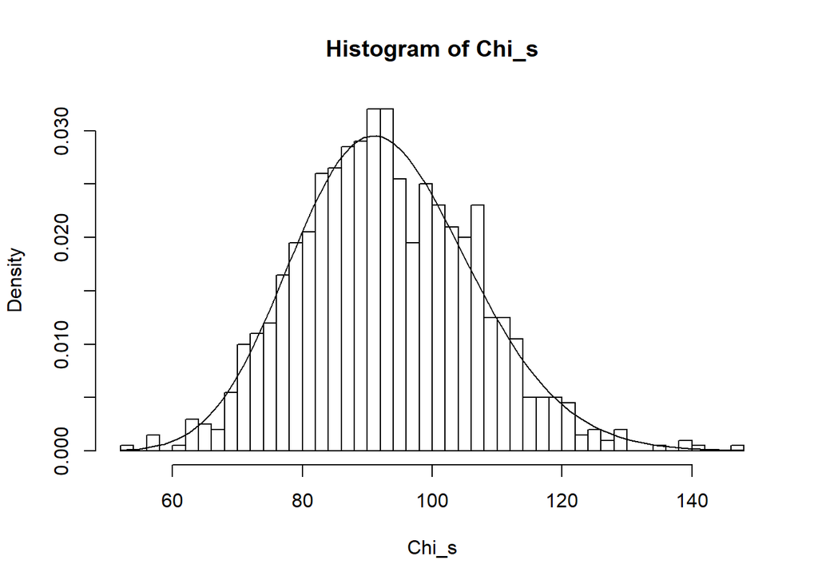

```r
hist(Chi_s,breaks=50,probability=TRUE)
curve(dchisq(x,93),add=T)
```